# Caso Especial. Comparar modelo regresión lineal simple VS Polinomial con Python. Datos Advertising

Luis Alberto Jimenez Sot

2022-09-21

# 1 Objetivo

Evaluar y comparar los modelos de regresión lineal simple y polinomial de segunda y quinta potencia con datos de Adverstising_WEB.csv y programación Python.

# 2 Descripción

Se cargan los datos de la dirección:https://raw.githubusercontent.com/rpizarrog/Analisis-Inteligente-de-datos/main/datos/Advertising_Web.csv

Los datos contienen variables que en el contexto se interpreta que son inversiones hechas de una empresa y las ventas de la misma, a tanta inversión de marketing en medios tales como TV, Radio, *NewsPapers* (medios impresos) y *Web* (digital) existe en relacuón a las ventas (*Sales*) generadas.

Se trata de comparar modelos predictivos para evaluar cuál es mejor con respecto a los estadísticos *R Square* y *RMSE*.

Las variables de interés serán:

- **TV** como variable independiente o la variable explicativa hacia la variables *Sales*
- **Sales** como variable dependiente que es la variable a predecir.
- Se construyen datos de entrenamiento y datos de validacion al 70 y 30% respectivamente

Se construyen el modelo de regresión lineal simple con los datos de entrenamiento y se evaluán los siguiente aspectos:

Se construye el modelo polinomial a la segunda potencia y quinta potencia con los datos de entrenamiento y se evalúan los siguientes aspectos.

# 3 Desarrollo

## 3.1 Cargar librerías

```python
import pandas as pd
import matplotlib.pyplot as plt
import numpy as np
from sklearn import linear_model
from sklearn.linear_model import LinearRegression
from sklearn.preprocessing import PolynomialFeatures # Polinomial
from sklearn.model_selection import train_test_split
from sklearn import metrics
from sklearn.metrics import mean_squared_error, r2_score
```

## 3.2 Cargar datos

```python
datos = pd.read_csv("https://raw.githubusercontent.com/rpizarrog/Analisis-Inteligente-de-datos/main/datos/Advertising_Web.csv", encoding='latin1')
```

Observar los primeros diez registros

```python
datos.head(10)
```

```
##    Unnamed: 0   X     TV  Radio  Newspaper         Web  Sales
## 0           1   1  230.1   37.8       69.2  306.634752   22.1
## 1           2   2   44.5   39.3       45.1  302.653070   10.4
## 2           3   3   17.2   45.9       69.3   49.498908    9.3
## 3           4   4  151.5   41.3       58.5  257.816893   18.5
## 4           5   5  180.8   10.8       58.4  195.660076   12.9
## 5           6   6    8.7   48.9       75.0   22.072395    7.2
## 6           7   7   57.5   32.8       23.5  246.811598   11.8
## 7           8   8  120.2   19.6       11.6  229.971459   13.2
## 8           9   9    8.6    2.1        1.0  144.617385    4.8
## 9          10  10  199.8    2.6       21.2  111.272264   10.6
```

## 3.3 Describir datos

```python
print("Observaciones y variables: ", datos.shape)
```

```
## Observaciones y variables:  (200, 7)
```

```python
print("Columnas y tipo de dato")
# datos.columns
```

```
## Columnas y tipo de dato
```

```python
datos.dtypes
```

```
## Unnamed: 0      int64
## X               int64
## TV            float64
## Radio         float64
## Newspaper     float64
## Web           float64
## Sales         float64
## dtype: object
```

### 3.3.1 Variable independiente y dependiente

Se identifican dos variables numéricas de interés:

*TV*: Inversión de publicidad a través de televisión

*Sales*: Ventas de la empresa.

Se define a la variable independiente como *TV* y la variable dependiente Sales, es decir, *TV* impacta sobre *Sales* o los valores de inversión de la variable Sales dependen de *TV*.

```python
datos['TV'].describe()
```

```
## count    200.000000
## mean     147.042500
## std       85.854236
## min        0.700000
## 25%       74.375000
## 50%      149.750000
## 75%      218.825000
## max      296.400000
## Name: TV, dtype: float64
```

```python
datos['Sales'].describe()
```

```
## count    200.000000
## mean      14.022500
## std        5.217457
## min        1.600000
## 25%       10.375000
## 50%       12.900000
## 75%       17.400000
## max       27.000000
## Name: Sales, dtype: float64
```

### 3.3.2 Visualizar la dispersión de los datos

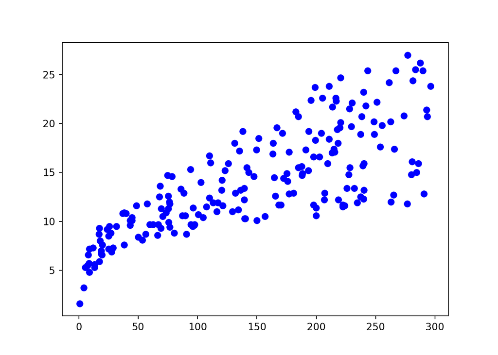

```python
plt.plot(datos['TV'], datos['Sales'], 'o', color= 'blue')
```

Se observa que la relación entre las dos variables no es del todo lineal.

## 3.4 Construir Datos de entrenamiento y validación

Los datos de entrenamiento son el 70% de los datos originales y los de validación el 30%.

Determinas las variables de interés en variables específicas en Python.

```python
TV = datos[['TV']].to_numpy()
Sales = datos[['Sales']].to_numpy()
```

Se utiliza el método *train_test_split()* que forma parte de la librería Scikit-Learn.

El argumento test_size establece el 30% para datos de validación por lo que el 70% pertenece a los datos de entrenamiento.

```python
TV_train, TV_test, Sales_train, Sales_test = train_test_split(TV, Sales, test_size=0.3, random_state=1271)
```

Ver los registros (cuántos) de cada conjunto de la variable TV.

```python
TV_train.shape
```

```
## (140, 1)
```

```python
TV_test.shape
```

```
## (60, 1)
```

Ver los primeros 10 registros de cada conjunto de datos de la variable TV.

```python
TV_train[1:10]
```

```
## array([[ 89.7],
##        [  5.4],
##        [175.7],
##        [216.4],
##        [ 74.7],
##        [184.9],
##        [250.9],
##        [248.8],
##        [262.7]])
```

```python
TV_test[1:10]
```

```
## array([[  8.7],
##        [139.5],
##        [ 19.4],
##        [228.3],
##        [187.9],
##        [ 97.2],
##        [253.8],
##        [  8.6],
##        [292.9]])
```

No deben ser los mismos… …

## 3.5 Modelo de regresión lineal simple

Se construye un modelo lineal con la función *LinearRegression*() y los valores ajustados con la función *fit*() del modelo construido.

La variable dependiente *Sales* está en función de la variable independiente *TV* de los datos de entrenamiento (train)

```python
modelo_ls = LinearRegression()
modelo_ls.fit(TV_train, Sales_train)
```

```
LinearRegression()
```

### 3.5.1 El valor de los coeficientes a y b

```python
a = modelo_ls.intercept_
b = modelo_ls.coef_
print("Valor de a: ", a)
```

```
## Valor de a:  [6.85295949]
```

```python
print("Valor de b; ", b)
```

```
## Valor de b;  [[0.04925669]]
```

### 3.5.2 Estimación lineal

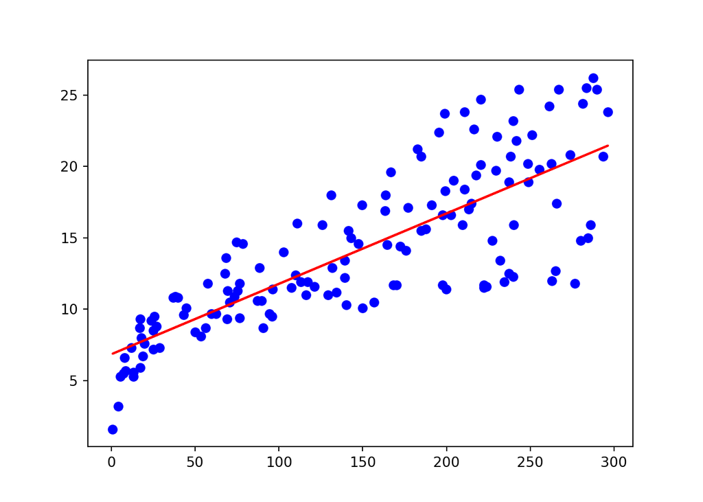

```python
linea_tendencia = modelo_ls.predict(TV_train)
plt.plot(TV_train, Sales_train, 'o', color= 'blue')
plt.plot(TV_train, linea_tendencia, color="red")
```

### 3.5.3 Predicciones del modelo

Las predicciones se hacen con el conjunto de datos de validación. Se muestran sólo los primeros diez valores de TV y las predicciones.

```python
TV_train[1:10]
```

```
## array([[ 89.7],
##        [  5.4],
##        [175.7],
##        [216.4],
##        [ 74.7],
##        [184.9],
##        [250.9],
##        [248.8],
##        [262.7]])
```

```python
predicciones = modelo_ls.predict(TV_test)
predicciones[1:10]
```

```
## array([[ 7.28149265],
##        [13.72426706],
##        [ 7.80853918],
##        [18.0982607 ],
##        [16.10829062],
##        [11.64070928],
##        [19.35430617],
##        [ 7.27656698],
##        [21.28024255]])
```

Se construye una tabla comparativa con los datos de validación y las predicciones generadas para comparar y generar el estadístico *rmse*.

Crear un data.frame llamado comparaciones a partir de la creación de un diccionario con los valores reales del conjunto de validación y las predicciones calculadas.

Con la función flatten().tolist() convierte el arreglo a una lista de una dimensión.

```python
diccionario = {'TV': TV_test.flatten().tolist(),
                'Real' : Sales_test.flatten().tolist(),
               'Predicho' : predicciones.flatten().tolist()}
diccionario
```

[output not shown]

```python
comparaciones = pd.DataFrame(diccionario)
comparaciones
```

```
##        TV  Real   Predicho
## 0   199.8  10.6  16.694445
## 1     8.7   7.2   7.281493
## 2   139.5  10.3  13.724267
## 3    19.4   6.6   7.808539
## 4   228.3  15.5  18.098261
## 5   187.9  14.7  16.108291
## 6    97.2   9.6  11.640709
## 7   253.8  17.6  19.354306
## 8     8.6   4.8   7.276567
## 9   292.9  21.4  21.280243
## 10  175.1  14.9  15.477805
## 11  240.1  13.2  18.679490
## 12  218.4  18.0  17.610620
## 13  280.7  16.1  20.679311
```

[output cut: 46 more lines]

### 3.5.4 Valor de R Square

Es el valor de la correlación al cuadrado de las predicciones y los valores reales.Se interpreta como la representación que tienen la variable independiente sobre la variable dependiente. En este caso, que tanto *TV* representa a *Sales* en los datos.

R2 es el coeficiente de determinación, y tiene que ver con la capacidad de un modelo para predecir futuros resultados.

```python
# Con lo real vs predicciones
r = np.corrcoef(comparaciones['Real'], comparaciones['Predicho'])
r = r ** 2
r = r.reshape(-1,2)
r = r[0, 1]
print('R Square :', np.round(r, 4) )
# con r2_score([2, 5, 9], [3, 5, 11])
```

```
## R Square : 0.531
```

```python
print('R Square :', r2_score(comparaciones['Real'], comparaciones['Predicho'] ))
```

```
## R Square : 0.5145324375428474
```

### 3.5.5 Evaluar predicciones con rmse

Se determina la variación de los valores reales contra las predicciones por medio del estadístico *rmse (Root Mean Stándar Error)* que servirá para compararse con otro modelo concluyendo que en el que tenga menor error es mas eficiente el modelo.

*rmse* Root Mean Stándar Error, este valor normalmente se compara contra otro modelo y el que esté mas cerca de cero es mejor.

*RMSE* es una forma útil de ver qué tan bien un modelo de regresión puede ajustarse a un conjunto de datos.

Cuanto mayor sea el *rmse*, mayor será la diferencia entre los valores predichos y reales, lo que significa que peor se ajusta un modelo de regresión a los datos. Por el contrario, cuanto más pequeño sea el rmse, mejor podrá un modelo ajustar los datos.

$$rmse = \sqrt{\frac{\sum(predicho_i - real_i)^{2}}{n}}$$

```python
print('Mean Squared Error: MSE', metrics.mean_squared_error(Sales_test, predicciones))
```

```
## Mean Squared Error: MSE 10.231369124969202
```

```python
print('Root Mean Squared Error RMSE:', np.sqrt(metrics.mean_squared_error(Sales_test, predicciones)))
```

```
## Root Mean Squared Error RMSE: 3.198651141492176
```

Construir un arreglo para ir guardando los valores de *rmse* y compararlos al final.

```python
rmse = []
rmse.append(np.sqrt(metrics.mean_squared_error(Sales_test, predicciones)))
rmse
```

```
## [3.198651141492176]
```

## 3.6 Modelo de regresión polinomial de segundo nivel

Desde Sklearn con PolynomialFeatures, se crea un objeto polinómico de segundo nivel. Se crea otro objeto de X_poly a partir de los datos de entrenamiento y finalmente se cra el modelo polinómico de segundo nivel.

Se carga la librería necesaria y se utiliza la variable *TV* de los datos de entrenamiento.

```python
from sklearn.preprocessing import PolynomialFeatures
poly_reg =  PolynomialFeatures(degree = 2)
TV_poly = poly_reg.fit_transform(TV_train)
modelo_poly2 = LinearRegression()
modelo_poly2.fit(TV_poly, Sales_train)
```

```
LinearRegression()
```

$$Y = \beta0 + \beta_1\cdot x_i+\beta_2\cdot x_i^2 + … \beta_n \cdot x_i^n$$

### 3.6.1 Curva de tendencia

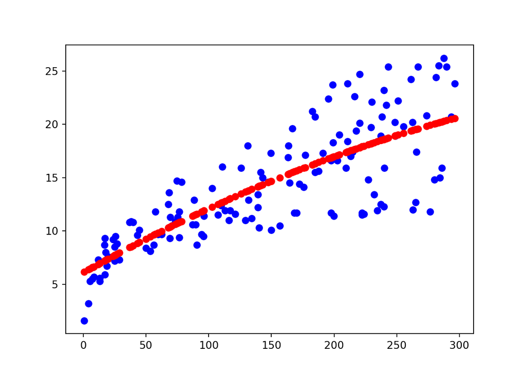

```python
curva_tendencia = modelo_poly2.predict(poly_reg.fit_transform(TV_train))
plt.scatter(TV_train, Sales_train, color = 'b', )
plt.scatter(TV_train, curva_tendencia, color='r', linestyle = 'solid')
plt.show()
```

### 3.6.2 Predicciones del modelo

Se utiliza la variable TV con los datos de validación

```python
predicciones = modelo_poly2.predict(poly_reg.fit_transform(TV_test))
predicciones
```

```
## array([[16.96457357],
##        [ 6.68111726],
##        [14.17182174],
##        [ 7.36755077],
##        [18.13946229],
##        [16.44644824],
##        [11.9639541 ],
##        [19.11174715],
##        [ 6.67464009],
##        [20.45779849],
##        [15.87101427],
##        [18.5986489 ],
##        [17.74189818],
##        [20.05661462],
##        [ 8.54183051],
##        [11.78308341],
##        [ 8.92627493],
##        [15.43179087],
##        [18.56802203],
##        [ 8.12798423],
##        [14.00695399],
##        [17.5409671 ],
##        [10.75170504],
##        [20.38671492],
##        [14.09204178],
##        [17.26597454],
##        [16.70100794],
##        [17.26176958],
##        [14.76081665],
##        [15.69656649],
##        [15.95761737],
##        [11.32824175],
##        [11.01884586],
##        [18.04012776],
##        [ 7.32940654],
##        [17.61920588],
##        [17.18588427],
##        [10.25633776],
##        [13.20548426],
##        [16.67921504],
##        [17.79880149],
##        [12.64306756],
##        [13.3401641 ],
##        [13.18989441],
##        [ 9.15596206],
##        [ 7.87845848],
##        [16.46854494],
##        [16.129582  ],
##        [12.36500424],
##        [10.72885271],
##        [18.12757998],
##        [10.20982603],
##        [12.13815159],
##        [10.79735466],
##        [17.74597016],
##        [11.98033499],
##        [17.67659069],
##        [ 8.84123606],
##        [19.92817058],
##        [13.95674759]])
```

Se construye tabla de comparaciones para determinar R *Square* y *rmse*

```python
diccionario = {'TV': TV_test.flatten().tolist(),
                'Real' : Sales_test.flatten().tolist(),
               'Predicho' : predicciones.flatten().tolist()}
diccionario
```

[output not shown]

```python
comparaciones = pd.DataFrame(diccionario)
comparaciones.head(10)
```

```
##       TV  Real   Predicho
## 0  199.8  10.6  16.964574
## 1    8.7   7.2   6.681117
## 2  139.5  10.3  14.171822
## 3   19.4   6.6   7.367551
## 4  228.3  15.5  18.139462
## 5  187.9  14.7  16.446448
## 6   97.2   9.6  11.963954
## 7  253.8  17.6  19.111747
## 8    8.6   4.8   6.674640
## 9  292.9  21.4  20.457798
```

### 3.6.3 Valor de R Square

```python
# Con lo real vs predicciones
r = np.corrcoef(comparaciones['Real'], comparaciones['Predicho'])
r = r ** 2
r = r.reshape(-1,2)
r = r[0, 1]
print('R Square :', np.round(r, 4) )
# con r2_score([2, 5, 9], [3, 5, 11])
```

```
## R Square : 0.5453
```

```python
print('R Square :', r2_score(comparaciones['Real'], comparaciones['Predicho'] ))
```

```
## R Square : 0.5279443390770824
```

### 3.6.4 Evaluar predicciones con rmse

Con la tabla de comparaciones se determina rmse.

```python
print('Mean Squared Error: MSE', metrics.mean_squared_error(Sales_test, predicciones))
```

```
## Mean Squared Error: MSE 9.948709425585866
```

```python
print('Root Mean Squared Error RMSE:', np.sqrt(metrics.mean_squared_error(Sales_test, predicciones)))
```

```
## Root Mean Squared Error RMSE: 3.1541574826862826
```

Agregar el valor de la métrica *rmse* al arreglo *rmse[]* creado anteriormente.

```python
rmse.append(np.sqrt(metrics.mean_squared_error(Sales_test, predicciones)))
rmse
```

```
## [3.198651141492176, 3.1541574826862826]
```

## 3.7 Modelo de regresión polinomial de quinto nivel

Se carga la librería necesaria y se utiliza la variable *TV* de los datos de entrenamiento.

```python
from sklearn.preprocessing import PolynomialFeatures
poly_reg =  PolynomialFeatures(degree = 5)
TV_poly = poly_reg.fit_transform(TV_train)
modelo_poly5 = LinearRegression()
modelo_poly5.fit(TV_poly, Sales_train)
```

```
LinearRegression()
```

$$Y = \beta0 + \beta_1\cdot x_i+\beta_2\cdot x_i^2 + \beta_3\cdot x_i^3
+\beta_4\cdot x_i^4 +\beta_5\cdot x_i^5$$